# 厚生労働省オープンデータ

日本の新型コロナウィルスに関する情報が抱える大きな問題の一つに、ソースごとの値が微妙にことなっていることが挙げられる。原因は明白で、総元締めであるはずの厚生労働省が各自治からの患者データを集計せずに各自治体のプレスリリースやウェブサイトの数値を積上げたものを発表しているからである。  
本来であれば医療機関->市町村->都道府県->厚生労働省が一気通貫して同じデータを扱えるようにすべきであり、このあたりの改革は、河野行政改革担当大臣に期待するところである。

さて、理想論はさておき、実際のデータはどのようになっていて、そこから何が読み取れるかを見てみる。

# 厚生労働省データ

厚生労働省の[オープンデータ](https://www.mhlw.go.jp/stf/covid-19/open-data.html)のページで公開しているデータは、あくまでも、**「国内事例」**のみであり、チャーター便、空港検疫、外国船籍の客船を除くデータになっている。なお、データによっては途中からデータソースが変更されているものがあるため可視化すると不自然な変動が見られる場合がある。

## Import

項目ごとに個別のCSVファイルになっている。

### 陽性者数

PCR検査で陽性が確定した「陽性者数」のデータ。厚生労働省が公開している陽者数のデータは単日のデータのみ。

```r
"https://www.mhlw.go.jp/content/pcr_positive_daily.csv" %>%
  readr::read_csv()
```

| 日付 | PCR 検査陽性者数(単日) |
| --- | --- |
| 2020/1/16 | 1 |
| 2020/1/17 | 0 |
| 2020/1/18 | 0 |
| 2020/1/19 | 0 |
| 2020/1/20 | 0 |
| 2020/1/21 | 0 |
| 2020/1/22 | 0 |
| 2020/1/23 | 0 |
| 2020/1/24 | 1 |
| 2020/1/25 | 1 |

[output cut: 306 more lines]

### 死亡者数

死亡者数のデータは、なぜか累計データだけが公開されている。

```r
"https://www.mhlw.go.jp/content/death_total.csv" %>%
  readr::read_csv()
```

| 日付 | 死亡者数 |
| --- | --- |
| 2020/2/14 | 1 |
| 2020/2/15 | 1 |
| 2020/2/16 | 1 |
| 2020/2/17 | 1 |
| 2020/2/18 | 1 |
| 2020/2/19 | 1 |
| 2020/2/20 | 1 |
| 2020/2/21 | 1 |
| 2020/2/22 | 1 |
| 2020/2/23 | 1 |

[output cut: 277 more lines]

### 入院治療等を要する者の数

いわゆる無症状患者などの軽症患者を除く陽性者の数。各報告日時点の集計値となっている。

```r
"https://www.mhlw.go.jp/content/cases_total.csv" %>%
  readr::read_csv()
```

| 日付 | 入院治療を要する者 |
| --- | --- |
| 2020/2/4 | 15 |
| 2020/2/5 | 16 |
| 2020/2/6 | 12 |
| 2020/2/7 | 12 |
| 2020/2/8 | 7 |
| 2020/2/9 | 7 |
| 2020/2/10 | 7 |
| 2020/2/11 | 6 |
| 2020/2/12 | 6 |
| 2020/2/13 | 6 |

[output cut: 287 more lines]

### PCR検査実施人数

件数ベースと人数ベースのデータが混在しているため数値が過大な傾向になっている。陽性者数と同じく単日。ただし、異なる数を合算しているので目安程度にしかならないと思われる。

```r
"https://www.mhlw.go.jp/content/pcr_tested_daily.csv" %>%
  readr::read_csv()
```

| 日付 | PCR 検査実施件数(単日) |
| --- | --- |
| 2020/2/5 | 4 |
| 2020/2/6 | 19 |
| 2020/2/7 | 9 |
| 2020/2/8 | 4 |
| 2020/2/9 | 10 |
| 2020/2/10 | 12 |
| 2020/2/11 | 4 |
| 2020/2/12 | 10 |
| 2020/2/13 | 16 |
| 2020/2/14 | 43 |

[output cut: 283 more lines]

### 重症者数

```r
"https://www.mhlw.go.jp/content/severe_daily.csv" %>%
  readr::read_csv()
```

| 日付 | 重症者数 |
| --- | --- |
| 2020/2/5 | 0 |
| 2020/2/6 | 0 |
| 2020/2/7 | 0 |
| 2020/2/8 | 0 |
| 2020/2/9 | 0 |
| 2020/2/10 | 0 |
| 2020/2/11 | 0 |
| 2020/2/12 | 0 |
| 2020/2/13 | 0 |
| 2020/2/14 | 2 |

[output cut: 286 more lines]

## Wrangle (tidy and transform)

各データを扱いやすいように変換する。

### 陽性者数

単日のデータなので暗黙の欠落は補完して、前日差、累計、移動平均を求める。

```r
df_mhlw <- "https://www.mhlw.go.jp/content/pcr_positive_daily.csv" %>%
  readr::read_csv() %>%
  dplyr::mutate(date = lubridate::as_date(`日付`)) %>%
  tidyr::complete(date = seq.Date(from = min(date), to = max(date), by = "day")) %>%
  dplyr::mutate(n = as.integer(`PCR 検査陽性者数(単日)`),
                diff = lagdiff(n),
                cum = cumsum(n),
                ma7 = ma7(n)) %>%
  dplyr::select(date, n, diff, cum, ma7)

df_mhlw
```

| date | n | diff | cum | ma7 |
| --- | --- | --- | --- | --- |
| 2020-01-16 | 1 | 1 | 1 | NA |
| 2020-01-17 | 0 | -1 | 1 | NA |
| 2020-01-18 | 0 | 0 | 1 | NA |
| 2020-01-19 | 0 | 0 | 1 | NA |
| 2020-01-20 | 0 | 0 | 1 | NA |
| 2020-01-21 | 0 | 0 | 1 | NA |
| 2020-01-22 | 0 | 0 | 1 | 0.1428571 |
| 2020-01-23 | 0 | 0 | 1 | 0.0000000 |
| 2020-01-24 | 1 | 1 | 2 | 0.1428571 |
| 2020-01-25 | 1 | 0 | 3 | 0.2857143 |

[output cut: 306 more lines]

### 死亡者数

陽性者数とは逆に短日の数値を求める。

```r
dead_mhlw <- "https://www.mhlw.go.jp/content/death_total.csv" %>%
  readr::read_csv() %>%
  dplyr::mutate(date = lubridate::as_date(`日付`)) %>%
  tidyr::complete(date = seq.Date(from = min(date), to = max(date), by = "day")) %>%
  dplyr::mutate(cum_dead = as.integer(`死亡者数`),
                dead = lagdiff(cum_dead),
                diff_dead = lagdiff(dead),
                ma7_dead = ma7(dead)) %>%
                # dead = cum_dead - dplyr::lag(cum_dead, default = 0)) %>%
  dplyr::select(date, dead, diff_dead, cum_dead, ma7_dead)

dead_mhlw
```

| date | dead | diff_dead | cum_dead | ma7_dead |
| --- | --- | --- | --- | --- |
| 2020-02-14 | 1 | 1 | 1 | NA |
| 2020-02-15 | 0 | -1 | 1 | NA |
| 2020-02-16 | 0 | 0 | 1 | NA |
| 2020-02-17 | 0 | 0 | 1 | NA |
| 2020-02-18 | 0 | 0 | 1 | NA |
| 2020-02-19 | 0 | 0 | 1 | NA |
| 2020-02-20 | 0 | 0 | 1 | 0.1428571 |
| 2020-02-21 | 0 | 0 | 1 | 0.0000000 |
| 2020-02-22 | 0 | 0 | 1 | 0.0000000 |
| 2020-02-23 | 0 | 0 | 1 | 0.0000000 |

[output cut: 277 more lines]

### 入院治療等を要する者の数

各報告日時点の集計値。

```r
patient_mhlw <- "https://www.mhlw.go.jp/content/cases_total.csv" %>%
  readr::read_csv() %>%
  dplyr::mutate(date = lubridate::as_date(`日付`)) %>%
  tidyr::complete(date = seq.Date(from = min(date), to = max(date), by = "day")) %>%
  dplyr::mutate(patient = as.integer(`入院治療を要する者`),
                diff_patient = lagdiff(patient)) %>%
  dplyr::select(date, patient, diff_patient)
patient_mhlw
```

| date | patient | diff_patient |
| --- | --- | --- |
| 2020-02-04 | 15 | 15 |
| 2020-02-05 | 16 | 1 |
| 2020-02-06 | 12 | -4 |
| 2020-02-07 | 12 | 0 |
| 2020-02-08 | 7 | -5 |
| 2020-02-09 | 7 | 0 |
| 2020-02-10 | 7 | 0 |
| 2020-02-11 | 6 | -1 |
| 2020-02-12 | 6 | 0 |
| 2020-02-13 | 6 | 0 |

[output cut: 287 more lines]

### PCR検査実施人数

```r
pcr_mhlw <- "https://www.mhlw.go.jp/content/pcr_tested_daily.csv" %>%
  readr::read_csv() %>%
  dplyr::mutate(date = lubridate::as_date(`日付`),
                pcr = as.integer(`PCR 検査実施件数(単日)`)) %>%
  dplyr::select(date, pcr) %>%
  tidyr::complete(date = seq.Date(from = min(date), to = max(date), by = "day"),
                  fill = list(pcr = 0L)) %>%
  dplyr::mutate(cum_pcr = cumsum(pcr),
                diff_pcr = lagdiff(pcr),
                ma7_pcr = ma7(pcr))
pcr_mhlw
```

| date | pcr | cum_pcr | diff_pcr | ma7_pcr |
| --- | --- | --- | --- | --- |
| 2020-02-05 | 4 | 4 | 4 | NA |
| 2020-02-06 | 19 | 23 | 15 | NA |
| 2020-02-07 | 9 | 32 | -10 | NA |
| 2020-02-08 | 4 | 36 | -5 | NA |
| 2020-02-09 | 10 | 46 | 6 | NA |
| 2020-02-10 | 12 | 58 | 2 | NA |
| 2020-02-11 | 4 | 62 | -8 | 8.857143 |
| 2020-02-12 | 10 | 72 | 6 | 9.714286 |
| 2020-02-13 | 16 | 88 | 6 | 9.285714 |
| 2020-02-14 | 43 | 131 | 27 | 14.142857 |

[output cut: 286 more lines]

### 重症者数

```r
si_mhlw <- "https://www.mhlw.go.jp/content/severe_daily.csv" %>%
  readr::read_csv() %>%
  dplyr::mutate(date = lubridate::as_date(`日付`),
                si = as.integer(`重症者数`)) %>%
  dplyr::select(date, si) %>%
  tidyr::complete(date = seq.Date(from = min(date), to = max(date), by = "day"),
                  fill = list(si = 0L)) %>%
  dplyr::mutate(cum_si = cumsum(si),
                diff_si = lagdiff(si),
                ma7_si = ma7(si))

si_mhlw
```

| date | si | cum_si | diff_si | ma7_si |
| --- | --- | --- | --- | --- |
| 2020-02-05 | 0 | 0 | 0 | NA |
| 2020-02-06 | 0 | 0 | 0 | NA |
| 2020-02-07 | 0 | 0 | 0 | NA |
| 2020-02-08 | 0 | 0 | 0 | NA |
| 2020-02-09 | 0 | 0 | 0 | NA |
| 2020-02-10 | 0 | 0 | 0 | NA |
| 2020-02-11 | 0 | 0 | 0 | 0.0000000 |
| 2020-02-12 | 0 | 0 | 0 | 0.0000000 |
| 2020-02-13 | 0 | 0 | 0 | 0.0000000 |
| 2020-02-14 | 2 | 2 | 2 | 0.2857143 |

[output cut: 286 more lines]

### 結合

上記のデータフレームをひとつにまとめる。

```r
x_mhlw <- df_mhlw %>%
  dplyr::left_join(dead_mhlw, by = c("date")) %>%
  dplyr::left_join(patient_mhlw, by = c("date")) %>%
  dplyr::left_join(pcr_mhlw, by = c("date")) %>%
  dplyr::left_join(si_mhlw, by = c("date")) %>%
  dplyr::select(date, n, diff, cum, ma7, dead, patient, pcr, si) %>%
  tidyr::replace_na(list(dead = 0L, patient = 0L, pcr = 0L, si = 0L)) %>%
  dplyr::mutate(diff_dead = lagdiff(dead), cum_dead = cumsum(dead),
                ma7_dead = ma7(dead), diff_patient = lagdiff(patient),
                diff_pcr = lagdiff(pcr), cum_pcr = cumsum(pcr),
                ma7_pcr = ma7(pcr),
                diff_si = lagdiff(si), cum_si = cumsum(si),
                ma7_si = ma7(si)) %>%
  dplyr::select(date, n, diff, cum, ma7, patient, diff_patient,
                dead, diff_dead, cum_dead, ma7_dead,
                pcr, diff_pcr, cum_pcr, ma7_pcr, si, diff_si, cum_si, ma7_si)
x_mhlw
```

| date | n | diff | cum | ma7 | patient | diff_patient | dead | diff_dead | cum_dead | ma7_dead | pcr | diff_pcr | cum_pcr | ma7_pcr | si | diff_si | cum_si | ma7_si |
| --- | --- | --- | --- | --- | --- | --- | --- | --- | --- | --- | --- | --- | --- | --- | --- | --- | --- | --- |
| 2020-01-16 | 1 | 1 | 1 | NA | 0 | 0 | 0 | 0 | 0 | NA | 0 | 0 | 0 | NA | 0 | 0 | 0 | NA |
| 2020-01-17 | 0 | -1 | 1 | NA | 0 | 0 | 0 | 0 | 0 | NA | 0 | 0 | 0 | NA | 0 | 0 | 0 | NA |
| 2020-01-18 | 0 | 0 | 1 | NA | 0 | 0 | 0 | 0 | 0 | NA | 0 | 0 | 0 | NA | 0 | 0 | 0 | NA |
| 2020-01-19 | 0 | 0 | 1 | NA | 0 | 0 | 0 | 0 | 0 | NA | 0 | 0 | 0 | NA | 0 | 0 | 0 | NA |
| 2020-01-20 | 0 | 0 | 1 | NA | 0 | 0 | 0 | 0 | 0 | NA | 0 | 0 | 0 | NA | 0 | 0 | 0 | NA |
| 2020-01-21 | 0 | 0 | 1 | NA | 0 | 0 | 0 | 0 | 0 | NA | 0 | 0 | 0 | NA | 0 | 0 | 0 | NA |
| 2020-01-22 | 0 | 0 | 1 | 0.1428571 | 0 | 0 | 0 | 0 | 0 | 0.0000000 | 0 | 0 | 0 | 0.000000e+00 | 0 | 0 | 0 | 0.0000000 |
| 2020-01-23 | 0 | 0 | 1 | 0.0000000 | 0 | 0 | 0 | 0 | 0 | 0.0000000 | 0 | 0 | 0 | 0.000000e+00 | 0 | 0 | 0 | 0.0000000 |
| 2020-01-24 | 1 | 1 | 2 | 0.1428571 | 0 | 0 | 0 | 0 | 0 | 0.0000000 | 0 | 0 | 0 | 0.000000e+00 | 0 | 0 | 0 | 0.0000000 |
| 2020-01-25 | 1 | 0 | 3 | 0.2857143 | 0 | 0 | 0 | 0 | 0 | 0.0000000 | 0 | 0 | 0 | 0.000000e+00 | 0 | 0 | 0 | 0.0000000 |

[output cut: 306 more lines]

## Visualize

### 陽性者数の推移

最近ではPCR検査の件数が大きく増えており、その感度が一説には約35%と言われていることからみても、陽性者数だけで議論することは意味がないと言われているが、まずは可視化する。

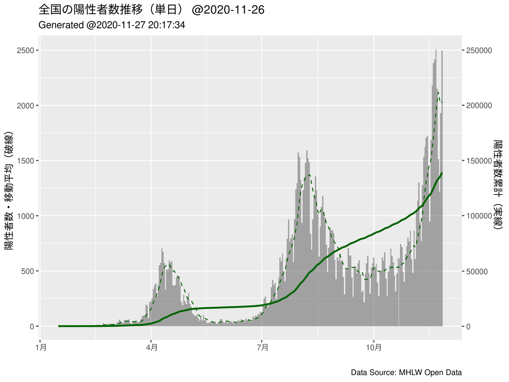

```r
scale_axis <- 100

x_mhlw %>%
  ggplot2::ggplot(ggplot2::aes(x = date)) +
    ggplot2::geom_bar(ggplot2::aes(y = n), stat = "identity",
                      width = 1.0, alpha = 0.5) +
    ggplot2::geom_line(ggplot2::aes(y = ma7), linetype = "dashed",
                       colour = "dark green", size = 0.5) +
    ggplot2::geom_line(ggplot2::aes(y = cum / scale_axis),
                       colour = "dark green", size = 1.0) +
    ggplot2::labs(title = paste0("全国の陽性者数推移（単日） @", datetime),
                  subtitle = subtitle, caption = caption,
                  x = "", y = "") +
    ggplot2::scale_y_continuous(
      name = "陽性者数・移動平均（破線）",
      sec.axis = ggplot2::sec_axis(~ . * scale_axis,
                                    name = "陽性者数累計（実線）")
    )
```

2020年10月29日の報道では陽性者数の累計が10万人を超えた（チャーター便、空港検疫など含む）と報道されていたが、2020-11-27 20:17:37 時点で厚生労働省が公開しているデータに基づくと 2020-11-26 の $139240$ 人である。このラグは集計方法に起因すると推定できる。

### 死亡者数の推移

陽性者数の推移に変わり着目されているのが死亡者数の推移である。まずは、単純な死亡者数の推移。

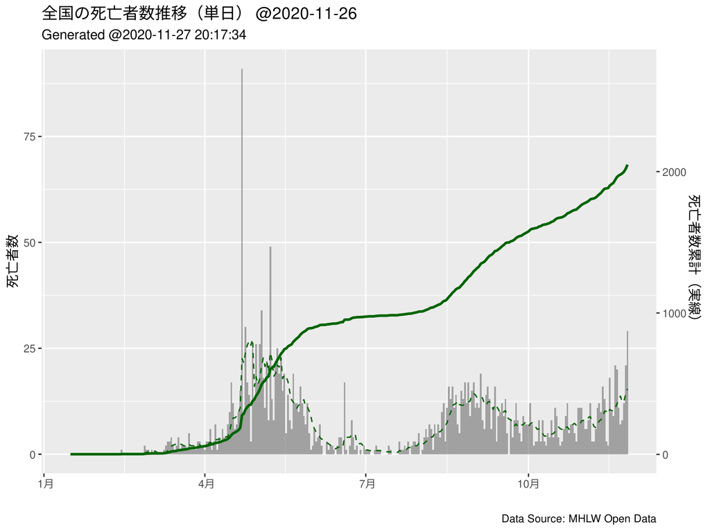

```r
scale_axis <- 30

x_mhlw %>%
  ggplot2::ggplot(ggplot2::aes(x = date)) +
    ggplot2::geom_bar(ggplot2::aes(y = dead), stat = "identity",
                      width = 1.0, alpha = 0.5) +
    ggplot2::geom_line(ggplot2::aes(y = ma7_dead), linetype = "dashed",
                       colour = "dark green", size = 0.5) +
    ggplot2::geom_line(ggplot2::aes(y = cum_dead / scale_axis),
                       colour = "dark green", size = 1.0) +
    ggplot2::labs(title = paste0("全国の死亡者数推移（単日） @", datetime),
                  subtitle = subtitle, caption = caption,
                  x = "", y = "") +
    ggplot2::scale_y_continuous(
      name = "死亡者数",
      sec.axis = ggplot2::sec_axis(~ . * scale_axis,
                                    name = "死亡者数累計（実線）")
    )
```

4月22日に90名超の死亡者が出ているのは「令和2年4月21日公表分から、データソースを従来の厚生労働省が把握した個票を積み上げたものから、各自治体がウェブサイトで公表している数等を積み上げたものに変更した。」ことが原因と考えられる。

### 入院治療等を要する者の推移

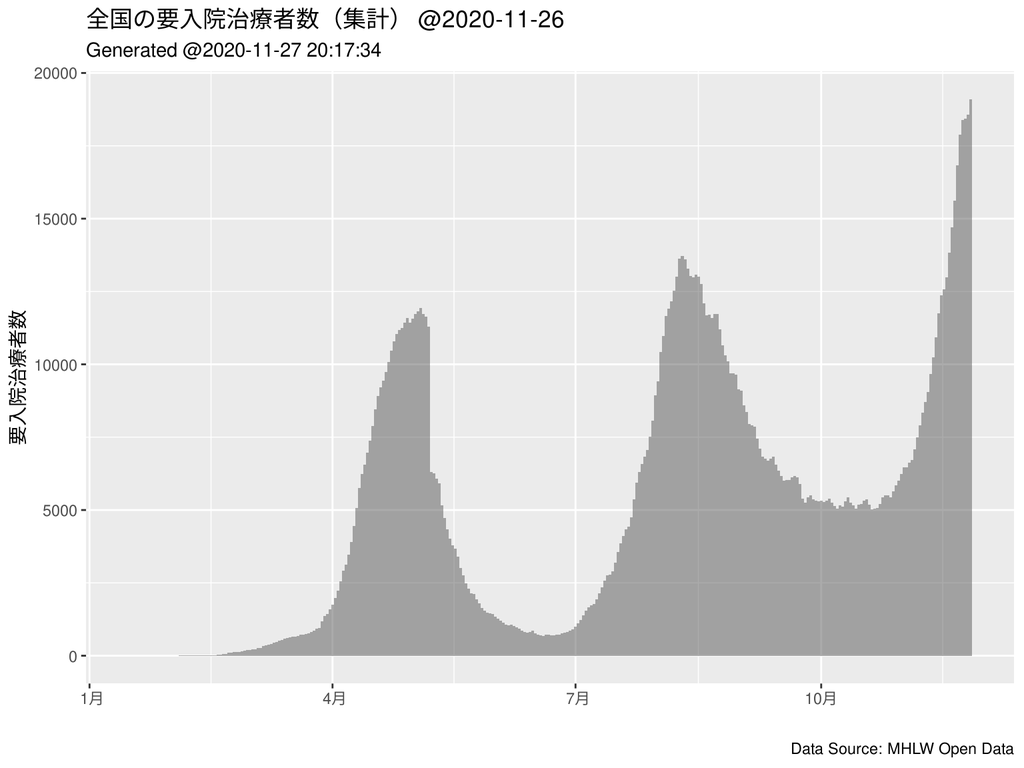

```r
x_mhlw %>%
  ggplot2::ggplot(ggplot2::aes(x = date)) +
    ggplot2::geom_bar(ggplot2::aes(y = patient), stat = "identity",
                      width = 1.0, alpha = 0.5) +
    ggplot2::labs(title = paste0("全国の要入院治療者数（集計） @", datetime),
                  subtitle = subtitle, caption = caption,
                  x = "", y = "要入院治療者数")
```

値が急激に変わっている部分が認められるので、前日比のデータをプロットしてみる。

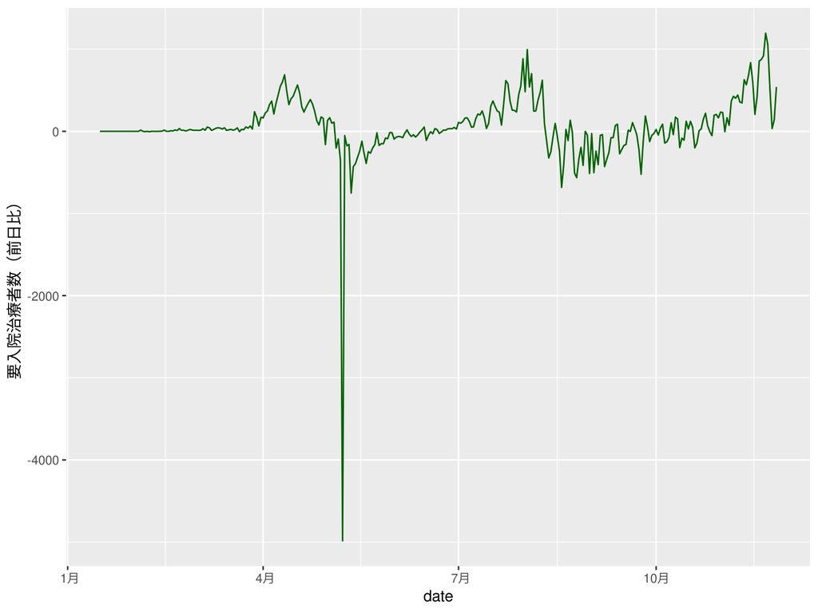

```r
x_mhlw %>%
  ggplot2::ggplot(ggplot2::aes(x = date)) +
    ggplot2::geom_line(ggplot2::aes(y = diff_patient), colour = "dark green") +
    ggplot2::labs(y = "要入院治療者数（前日比）")
```

5月8日の時点で急激に値が変わっているのが分かる。これは、[オープンデータのページ](https://www.mhlw.go.jp/stf/covid-19/open-data.html)に記載されているように「令和2年（2020年）5月8日公表分から、データソースを従来の厚生労働省が把握した個票を積み上げたものから、各自治体がウェブサイトで公表している数等を積み上げたものに変更した。」ためである。

### PCR検査実施人数の推移

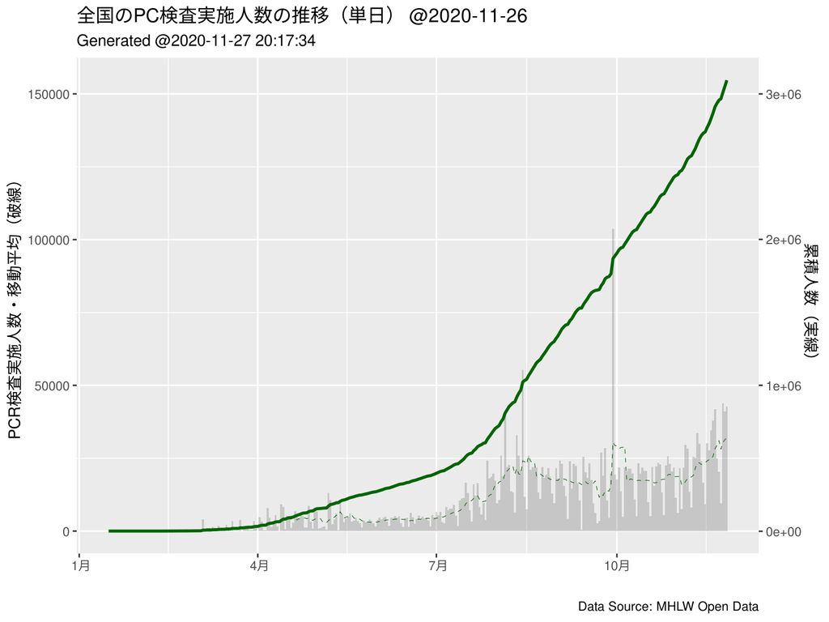

```r
scale_axis <- 20

x_mhlw %>%
  ggplot2::ggplot(ggplot2::aes(x = date)) +
    ggplot2::geom_bar(ggplot2::aes(y = pcr), stat = "identity",
                      width = 1.0, alpha = 0.25) +
    ggplot2::geom_line(ggplot2::aes(y = ma7_pcr), colour = "dark green",
                       linetype = "dashed", size = 0.2) +
    ggplot2::geom_line(ggplot2::aes(y = cum_pcr / scale_axis),
                       colour = "dark green", size = 1.0) +
    ggplot2::labs(title = paste0("全国のPC検査実施人数の推移（単日） @", datetime),
                  subtitle = subtitle, caption = caption,
                  x = "", y = "") +
    ggplot2::scale_y_continuous(
      name = "PCR検査実施人数・移動平均（破線）",
      sec.axis = ggplot2::sec_axis(~ . * scale_axis,
                                    name = "累積人数（実線）")
    )
```

### 重症者数の推移

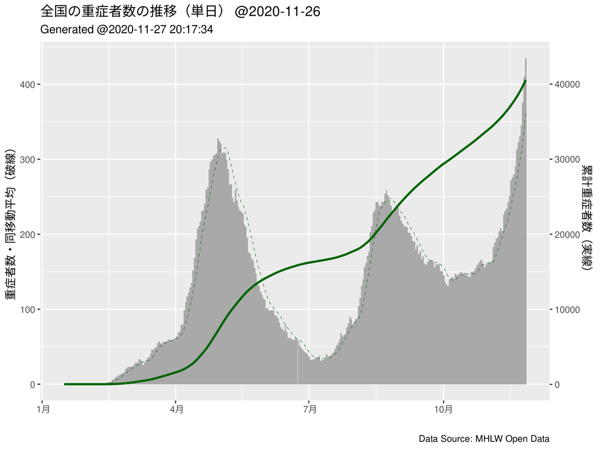

```r
scale_axis <- 100

x_mhlw %>%
  ggplot2::ggplot(ggplot2::aes(x = date)) +
    ggplot2::geom_bar(ggplot2::aes(y = si), stat = "identity",
                      fill = "dark gray", width = 1.0, alpha = 1.0) +
    ggplot2::geom_line(ggplot2::aes(y = ma7_si), colour = "dark green",
                       linetype = "dashed", size = 0.2) +
    ggplot2::geom_line(ggplot2::aes(y = cum_si / scale_axis),
                       colour = "dark green", size = 1.0) +
    ggplot2::labs(title = paste0("全国の重症者数の推移（単日） @", datetime),
                  subtitle = subtitle, caption = caption,
                  x = "", y = "") +
    ggplot2::scale_y_continuous(
      name = "重症者数・同移動平均（破線）",
      sec.axis = ggplot2::sec_axis(~ . * scale_axis,
                                    name = "累計重症者数（実線）")
    )
```

### 陽性者数 vs 検査人数

検査人数が増えたから陽性者数も増えたと言われているが、本当なのか確認のためのプロットしてみる。

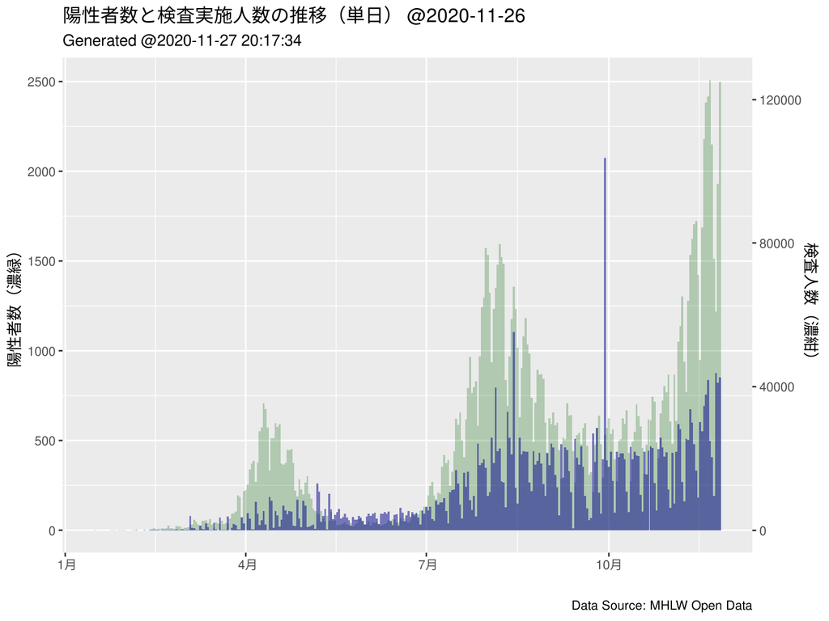

```r
scale_axis <- 50

x_mhlw %>%
  ggplot2::ggplot(ggplot2::aes(x = date)) +
    ggplot2::geom_bar(ggplot2::aes(y = n), stat = "identity",
                      width = 1.0, alpha = 0.25, fill = "dark green") +
    ggplot2::geom_bar(ggplot2::aes(y = pcr / scale_axis), stat = "identity",
                      width = 1.0, alpha = 0.5, fill = "dark blue") +
    ggplot2::labs(title = paste0("陽性者数と検査実施人数の推移（単日） @", datetime),
                  subtitle = subtitle, caption = caption,
                  x = "", y = "") +
    ggplot2::scale_y_continuous(
      name = "陽性者数（濃緑）",
      sec.axis = ggplot2::sec_axis(~ . * scale_axis,
                                   name = "検査人数（濃紺）")
    )
```

「令和2年9月29日より、福岡県における民間検査機関等での実施件数（過去行われたものも含む）を計上している。」ため異常値になっている9月29日のPCR検査実施人数のデータを削除しておく。そもそも、過去のデータを単日で積上げてしまうやり方は非常に疑問である。  
傾向を把握しやすくするために両者とも7日間の移動平均も合わせてプロットする。

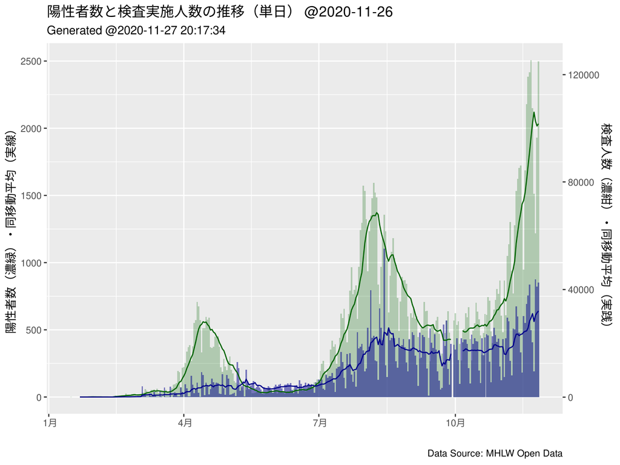

```r
scale_axis <- 50

x_mhlw %>%
  dplyr::filter(date != lubridate::as_date("2020-09-29")) %>%
  tidyr::complete(date = seq.Date(from = min(date), to = max(date), by = "day")) %>%
  dplyr::mutate(ma = zoo::rollmeanr(n, k = 7L, na.pad = TRUE),
                pcr_ma = zoo::rollmeanr(pcr, k = 7L, na.pad = TRUE)) %>%
  ggplot2::ggplot(ggplot2::aes(x = date)) +
    ggplot2::geom_bar(ggplot2::aes(y = n), stat = "identity",
                      width = 1.0, alpha = 0.25, fill = "dark green") +
    ggplot2::geom_bar(ggplot2::aes(y = pcr / scale_axis), stat = "identity",
                      width = 1.0, alpha = 0.5, fill = "dark blue") +
    ggplot2::geom_line(ggplot2::aes(y = ma), colour = "dark green") +
    ggplot2::geom_line(ggplot2::aes(y = pcr_ma / scale_axis), color = "dark blue") +
    ggplot2::labs(title = paste0("陽性者数と検査実施人数の推移（単日） @", datetime),
                  subtitle = subtitle, caption = caption,
                  x = "", y = "") +
    ggplot2::scale_y_continuous(
      name = "陽性者数（濃緑）・同移動平均（実線）",
      sec.axis = ggplot2::sec_axis(~ . * scale_axis,
                                   name = "検査人数（濃紺）・同移動平均（実践）")
    )
```

検査を増やしたから陽性者が増えているというより、陽性者が増えたから（濃厚接触者などの）検査が増えたという印象を受ける。

### 陽性者数 vs 死亡者数

陽性者数の増加は検査人数の増加にほぼ比例していると見ることができるが、死者数のはどうであろうか？4月22日は異常値として除いておく。

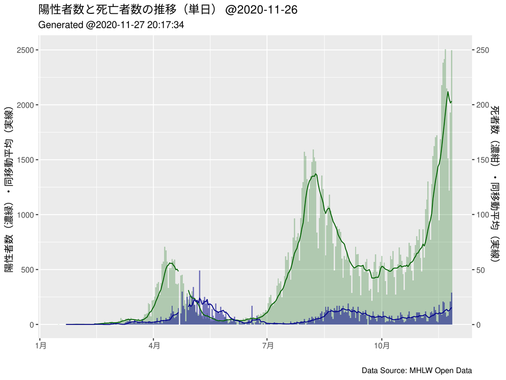

```r
scale_axis <- (1/10)

x_mhlw %>%
  dplyr::filter(date != lubridate::as_date("2020-04-22")) %>%
  tidyr::complete(date = seq.Date(from = min(date), to = max(date), by = "day")) %>%
  dplyr::mutate(ma = zoo::rollmeanr(n, k = 7L, na.pad = TRUE),
                dead_ma = zoo::rollmeanr(dead, k = 7L, na.pad = TRUE)) %>%
  ggplot2::ggplot(ggplot2::aes(x = date)) +
    ggplot2::geom_bar(ggplot2::aes(y = n), stat = "identity",
                      width = 1.0, alpha = 0.25, fill = "dark green") +
    ggplot2::geom_bar(ggplot2::aes(y = dead / scale_axis), stat = "identity",
                      width = 1.0, alpha = 0.5, fill = "dark blue") +
    ggplot2::geom_line(ggplot2::aes(y = ma), colour = "dark green") +
    ggplot2::geom_line(ggplot2::aes(y = dead_ma / scale_axis), color = "dark blue") +
    ggplot2::labs(title = paste0("陽性者数と死亡者数の推移（単日） @", datetime),
                  subtitle = subtitle, caption = caption,
                  x = "", y = "") +
    ggplot2::scale_y_continuous(
      name = "陽性者数（濃緑）・同移動平均（実線）",
      sec.axis = ggplot2::sec_axis(~ . * scale_axis,
                                   name = "死者数（濃紺）・同移動平均（実線）")
    )
```

陽性者が増加してから3〜4週間ほど遅れて死亡者数が増える傾向が、4月と8月の陽性者数のピークからよも取れる。しかし、両ピークを比較すると8月のピーク時の方が陽性者数に対する死者数の割合が低くなっている。

### 要入院治療者数 vs 死亡者数

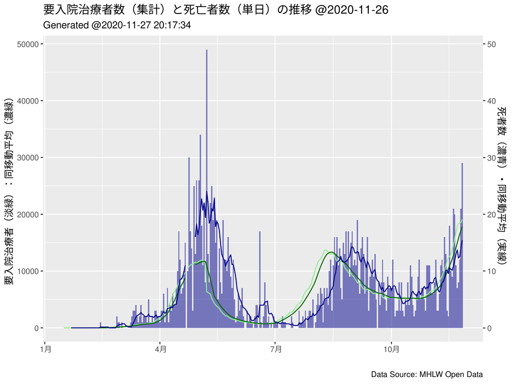

```r
scale_axis <- 0.001

x_mhlw %>%
  dplyr::filter(date != lubridate::as_date("2020-04-22")) %>%
  tidyr::complete(date = seq.Date(from = min(date), to = max(date), by = "day")) %>%
  dplyr::mutate(patient_ma = zoo::rollmeanr(patient, k = 7L, na.pad = TRUE),
                dead_ma = zoo::rollmeanr(dead, k = 7L, na.pad = TRUE)) %>%
  ggplot2::ggplot(ggplot2::aes(x = date)) +
    ggplot2::geom_bar(ggplot2::aes(y = dead / scale_axis), stat = "identity",
                      width = 1.0, alpha = 0.5, fill = "dark blue") +
    ggplot2::geom_line(ggplot2::aes(y = patient), colour = "light green") +
    ggplot2::geom_line(ggplot2::aes(y = patient_ma), colour = "dark green") +
    ggplot2::geom_line(ggplot2::aes(y = dead_ma / scale_axis), color = "dark blue") +
    ggplot2::labs(title = paste0("要入院治療者数（集計）と死亡者数（単日）の推移 @", datetime),
                  subtitle = subtitle, caption = caption,
                  x = "", y = "") +
    ggplot2::scale_y_continuous(
      name = "要入院治療者（淡緑）：同移動平均（濃緑）",
      sec.axis = ggplot2::sec_axis(~ . * scale_axis,
                                   name = "死者数（濃青）・同移動平均（実線）")
    )
```

当然と言えるが、要入院治療者が増えると、その数週間後に死亡者数が増えていることが分かる。